# TRIX_sharemed

SZ

28/9/2021

## Trix index on the Cadeau dominio

$$TRIX= \frac {k}{n}\sum_{i=1}^n\frac{(logM_i-logL_i)}{(logU_i-logL_i)}$$
The TRIX index was developed b Vollenweider et al. (1992)

E. Fiori et al.: Trophic index (TRIX) values for the Adriatic Sea basin

| TRIX units | Conditions | Trophic state |
| --- | --- | --- |
| 0–4 | Oligotrophic | Elevated |
| 4–5 |  | Good |
| 5–6 |  | Mediocre |
| 6–10 | Eutrophic | Bad |

In addition to TRIX, an efficiency coefficient can also be defined (Giovanardi and Vollenweider, 2004) as the logarithm of the ratio between the two aggregated main components of the TRIX. The efficiency coefficient can be considered a supplementary index with which to evaluate the nutrient utilization of the system.

$$eff.coeff= log\biggl( \frac{Chl \times Do}{DIN \times TP}\biggl)$$

C’e’ un file per anno Ogni file contiene 5 variabili: TRIX, OXY_dev_da_sat_perc, DIN, TP, CHL in mg/m3 Ogni variabile contiene 12 frame (uno al mese) Ci sono 3 calcoli delle medie verticali: _0_0 solo strato superficiale _0_25 media dei primi 25 m _0_150 media dei primi 150 m

```r
trix_2017 <- nc_open("C:/Users/Acer/Google Drive/ASSEGNO DI RICERCA/SHAREMED_mio/TRIX/TRIX2017.nc")
```

```r
year <- c(2006,2007,2008,2009,2010,2011,2012,2013,2014,2015,2016,2017)#Once you have a stack


trix_0_0<-stack(trix_all_files, varname="TRIX_0_0")
year <- format(as.Date(names(trix_0_0), format = "X%Y"), format = "%Y")
names(trix_0_0) <- paste0(rep(2006:2017, each=12), 1:12)
trix_0_0
```

```
## class      : RasterStack
## dimensions : 300, 494, 148200, 144  (nrow, ncol, ncell, nlayers)
## resolution : 0.0078125, 0.0078125  (x, y)
## extent     : 12.21875, 16.07812, 43.46875, 45.8125  (xmin, xmax, ymin, ymax)
## crs        : +proj=longlat +datum=WGS84 +no_defs
## names      : X20061, X20062, X20063, X20064, X20065, X20066, X20067, X20068, X20069, X200610, X200611, X200612, X20071, X20072, X20073, ...
```

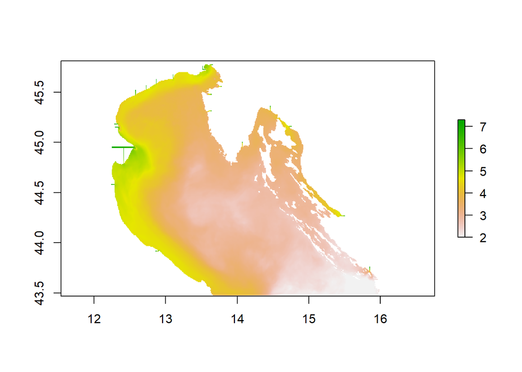

```r
plot(trix_0_0[[144]])
```

##calculate the climatological mean

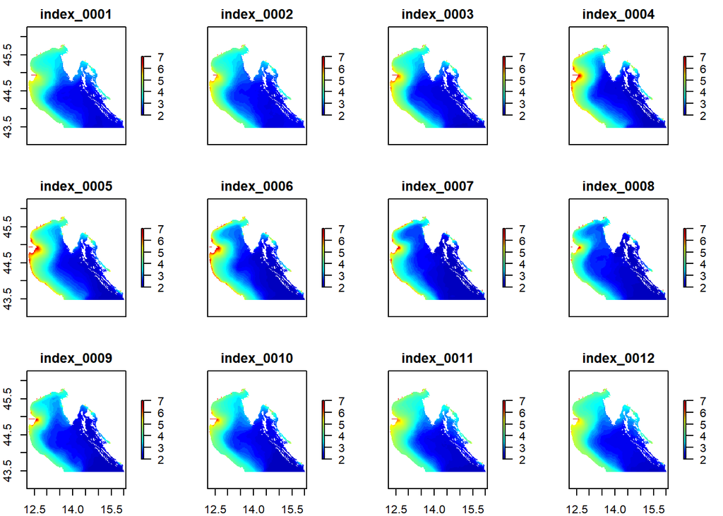

```r
yr_trix_00 = stackApply(trix_0_0, indices=year, fun=mean)
library(colorRamps)
col <- colorRamps::matlab.like2
plot(yr_trix_00, col=col(40),  zlim = c(2, 7))
```

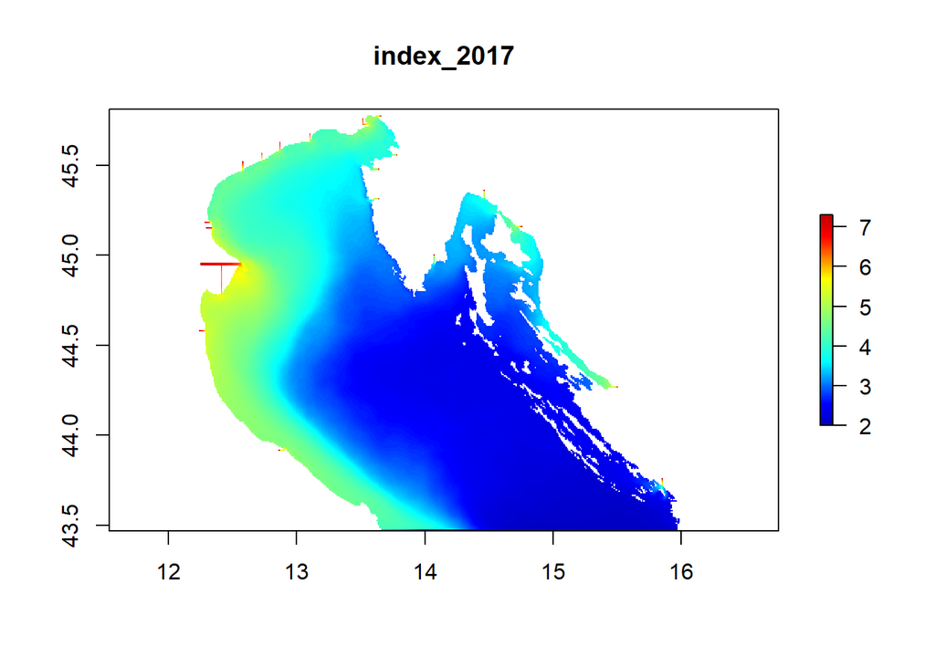

```r
plot(yr_trix_00[[12]], col=col(140), main="index_2017")
```

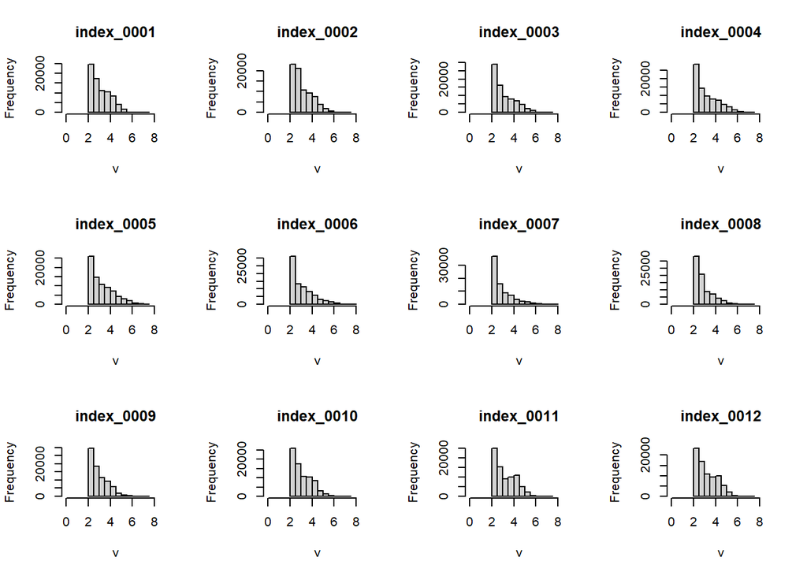

```r
# create histograms of each raster
hist(yr_trix_00,
     xlim = c(0, 9))
```